# Data table preparation and MAGEcK Analysis for B-ALL

## In Vivo Pool B

```r
invivo.poolB.1 <- ldf.200406[[4]][c(1,4)]
invivo.poolB.2 <- ldf.200406[[20]][c(1,5,6,7,8,9,10,11,12,14,15,16)]
invivo.poolB.3 <- ldf.200627[[58]][c(1,3,4,5,6,7,8)]
invivo.poolB.4 <- ldf.200627[[63]][c(1,14,15,16,17,30,31)]


invivo.poolB <- merge(x=invivo.poolB.1,y=invivo.poolB.2, by.x=c("Construct.Barcode"),by.y=c("Construct.Barcode"), all=TRUE)
invivo.poolB <- merge(x=invivo.poolB,y=invivo.poolB.3, by.x=c("Construct.Barcode"),by.y=c("Construct.Barcode"), all=TRUE)
invivo.poolB <- merge(x=invivo.poolB,y=invivo.poolB.4, by.x=c("Construct.Barcode"),by.y=c("Construct.Barcode"), all=TRUE)
invivo.poolB <- merge(x=invivo.poolB,y=sgRNAs.gene, by.x=c("Construct.Barcode"),by.y=c("Barcode.Sequence"), all=FALSE, all.x=TRUE)

col.viv.poolB <- colnames(invivo.poolB)
```

```r
# reorder columns
invivo.poolB.reorder <- invivo.poolB[,c(1,26,2,
                                3,5,7,9,12,
                                15,17,25,
                                20,21,22,23,
                                4,6,8,10,11,13,
                                14,16,18,19,24)]

# replace NA values with 0
invivo.poolB.reorder <- replace(invivo.poolB.reorder, is.na(invivo.poolB.reorder), 0)
# Write to table for mageck run
write_delim(invivo.poolB.reorder,file="invivo.poolB.txt", delim = '\t')
```

### results import and plotting

```r
files.toPlot <- list.files(pattern=glob2rx("invivo.poolB_*gene_summary.txt"), full.names=FALSE)
files.toPlot <- str_replace(files.toPlot, ".gene_summary.txt", "")
files.toPlot
```

```
## [1] "invivo.poolB_all_v_input"
## [2] "invivo.poolB_BM_hEGFRv3_15m_v_input"
## [3] "invivo.poolB_BM_mCD19_10m_v_BM_hEGFRv3_15m"
## [4] "invivo.poolB_BM_mCD19_15m_v_BM_hEGFRv3_15m"
## [5] "invivo.poolB_SP_mCD19_10m_v_SP_hEGFRv3_15m"
```

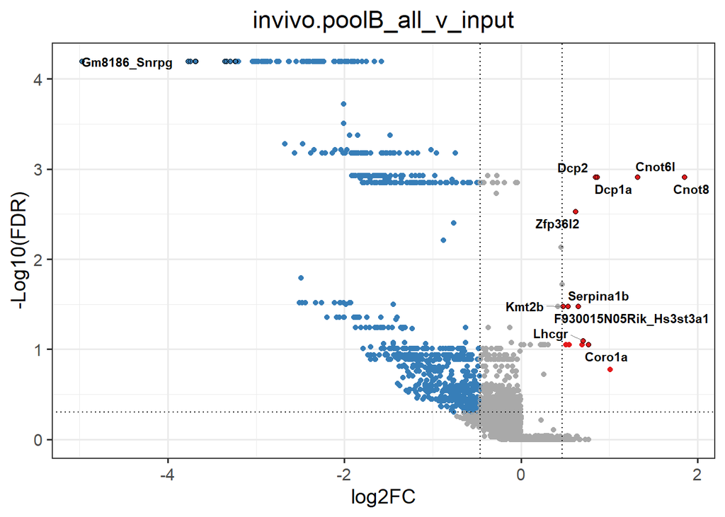

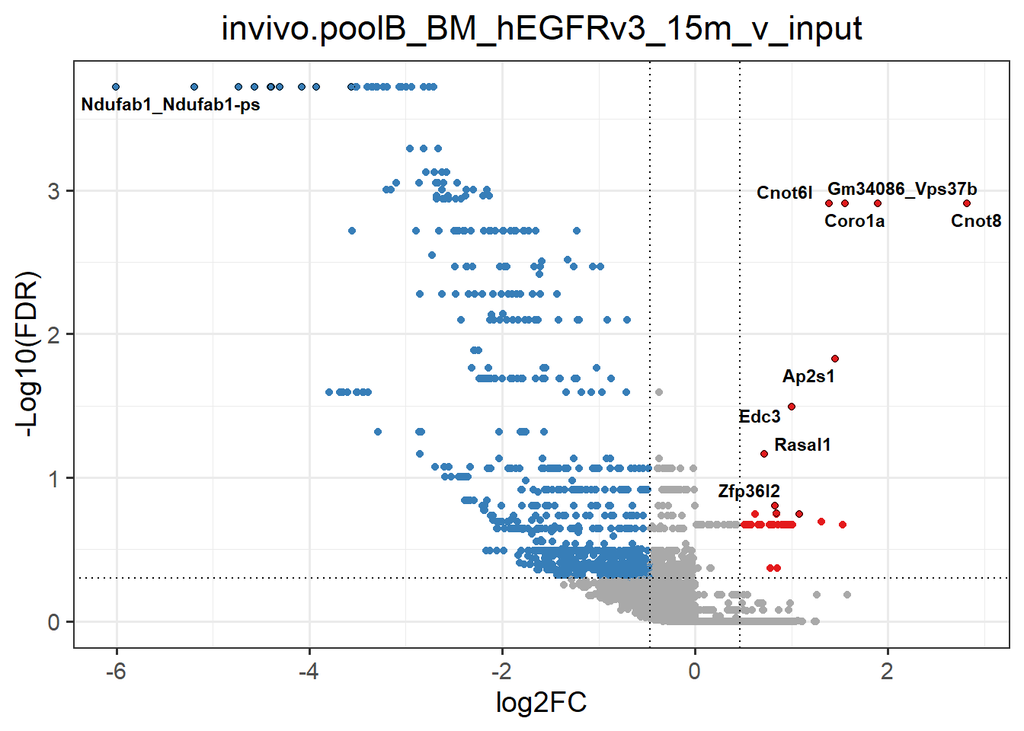

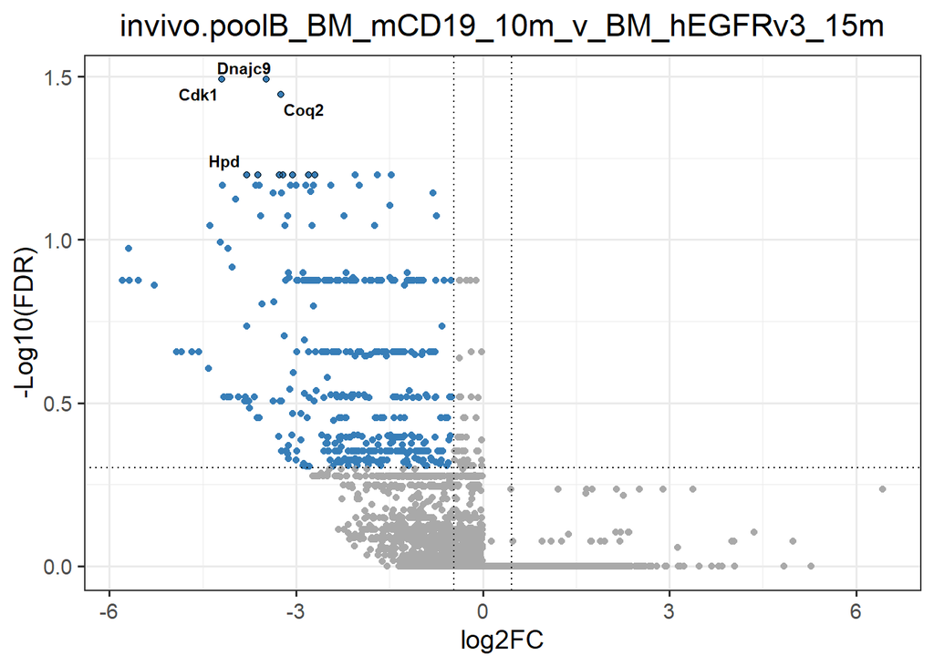

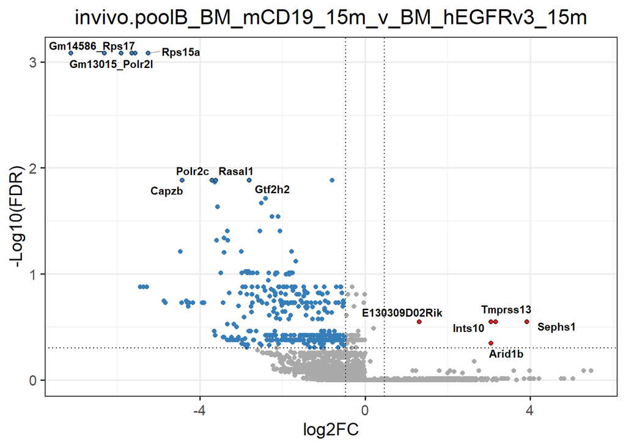

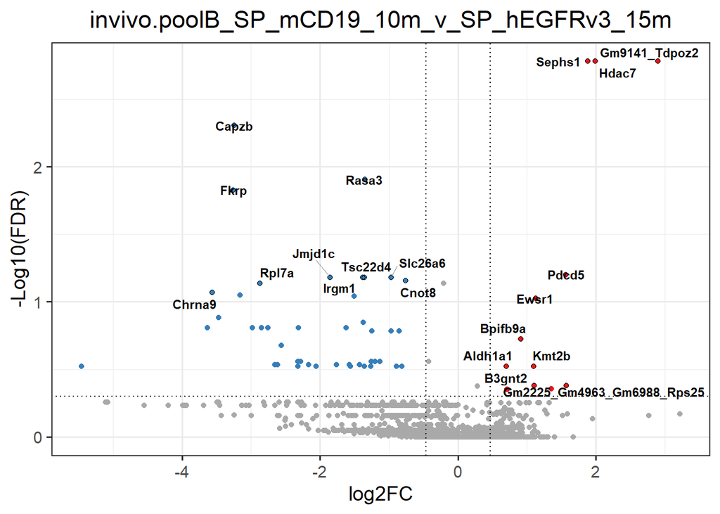

```r
for (i in files.toPlot){
  assign(paste0(i,".gdata"),ReadRRA(paste0(i,".gene_summary.txt"), score = c("lfc", "rra")[1]))
  assign(paste0(i,".sdata"),ReadsgRRA(paste0(i,".sgrna_summary.txt")))
}

for (i in files.toPlot){
  x <- get(paste0(i,".gdata"))
  print(plot_gdata_volcano(x))
}
```

## In Vivo Pool C

```r
invivo.poolC.1 <- ldf.200406[[2]][c(1,5)]
invivo.poolC.2 <- ldf.200406[[19]][c(1,17,18,19,20,21,22,23,24,26)]
invivo.poolC.3 <- ldf.200627[[56]][c(1,9,10,11,12,13,14,15,16,17)]
invivo.poolC.4 <- ldf.200627[[62]][c(1,18,19,20,21,22)]

invivo.poolC <- merge(x=invivo.poolC.1,y=invivo.poolC.2, by.x=c("Construct.Barcode"),by.y=c("Construct.Barcode"), all=TRUE)
invivo.poolC <- merge(x=invivo.poolC,y=invivo.poolC.3, by.x=c("Construct.Barcode"),by.y=c("Construct.Barcode"), all=TRUE)
invivo.poolC <- merge(x=invivo.poolC,y=invivo.poolC.4, by.x=c("Construct.Barcode"),by.y=c("Construct.Barcode"), all=TRUE)
invivo.poolC <- merge(x=invivo.poolC,y=sgRNAs.gene, by.x=c("Construct.Barcode"),by.y=c("Barcode.Sequence"), all=FALSE, all.x=TRUE)

col.viv.poolC <- colnames(invivo.poolC)
```

```r
# reorder columns

invivo.poolC.reorder <- invivo.poolC[,c(1,26,2,
                                3,5,7,9,
                                13,15,18,20,
                                21,22,23,24,25,
                                4,6,8,10,11,
                                12,14,16,17,19)]

# replace NA values with 0
invivo.poolC.reorder <- replace(invivo.poolC.reorder, is.na(invivo.poolC.reorder), 0)
# Write to table for mageck run
write_delim(invivo.poolC.reorder,file="invivo.poolC.txt", delim = '\t')
```

### results import and plotting

```r
files.toPlot <- list.files(pattern=glob2rx("invivo.poolC_*gene_summary.txt"), full.names=FALSE)
files.toPlot <- str_replace(files.toPlot, ".gene_summary.txt", "")
files.toPlot
```

```
## [1] "invivo.poolC_all_v_input"
## [2] "invivo.poolC_BM_hEGFRv3_15m_v_input"
## [3] "invivo.poolC_BM_mCD19_10m_v_BM_hEGFRv3_15m"
## [4] "invivo.poolC_BM_mCD19_15m_v_BM_hEGFRv3_15m"
## [5] "invivo.poolC_SP_mCD19_10m_v_SP_hEGFRv3_15m"
```

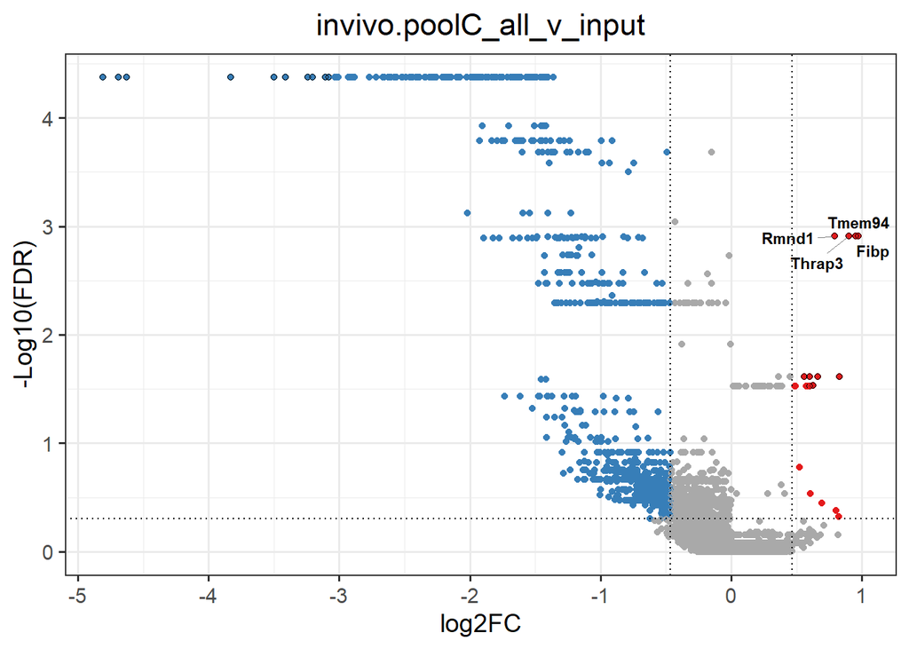

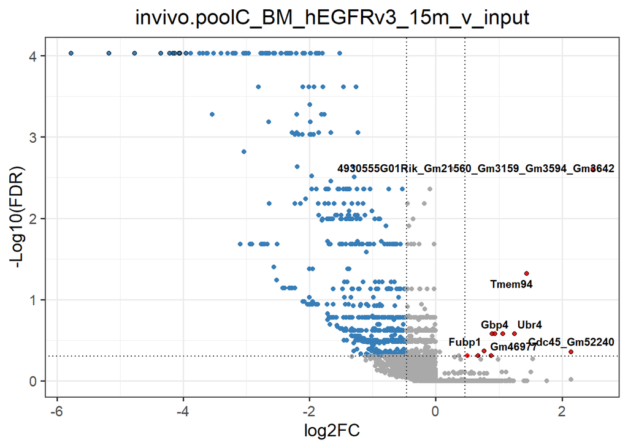

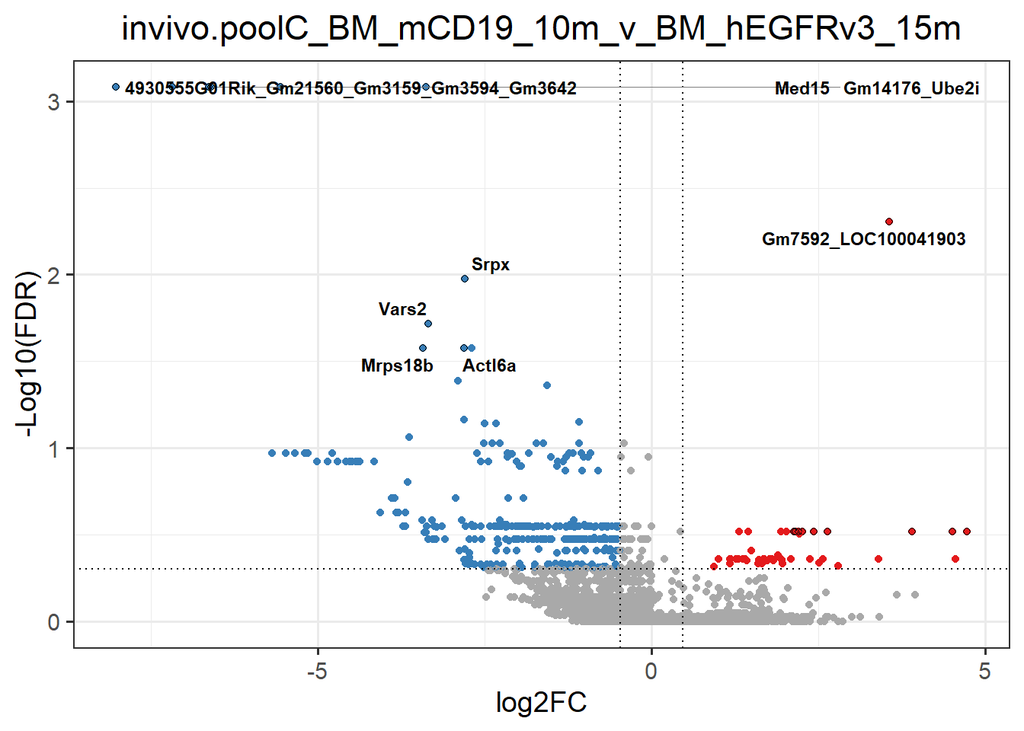

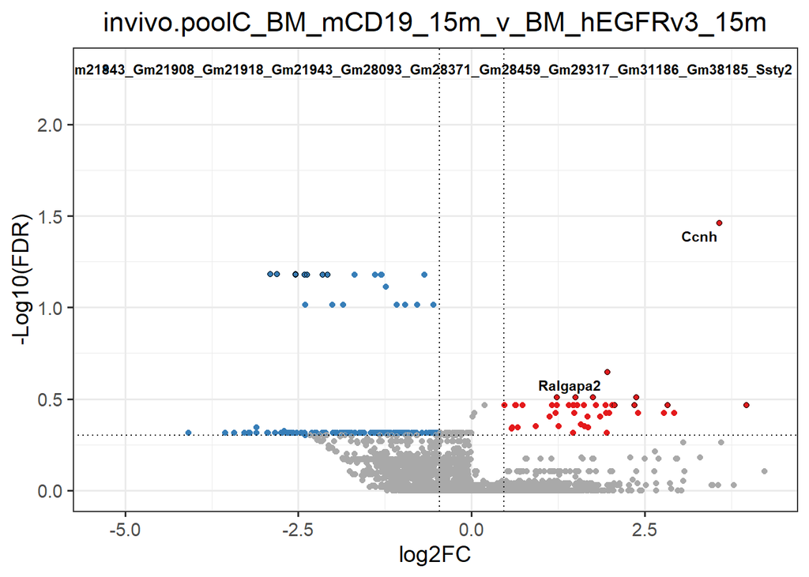

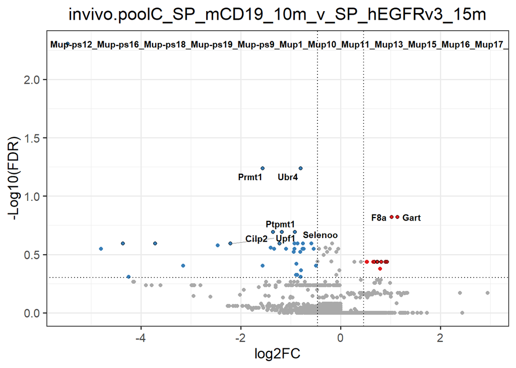

```r
for (i in files.toPlot){
  assign(paste0(i,".gdata"),ReadRRA(paste0(i,".gene_summary.txt"), score = c("lfc", "rra")[1]))
  assign(paste0(i,".sdata"),ReadsgRRA(paste0(i,".sgrna_summary.txt")))
}

for (i in files.toPlot){
  x <- get(paste0(i,".gdata"))
  print(plot_gdata_volcano(x))
}
```

## In Vivo Pool D

```r
invivo.poolD.1 <- ldf.200406[[3]][c(1,9)]
invivo.poolD.2 <- ldf.200627[[51]][c(1,14,15,16,17,18,19,30,31,32,33,34,35,36,37,38)]
invivo.poolD.3 <- ldf.200627[[57]][c(1,18,19,20,21,22,23,24,25,26,27)]

invivo.poolD <- merge(x=invivo.poolD.1,y=invivo.poolD.2, by.x=c("Construct.Barcode"),by.y=c("Construct.Barcode"), all=TRUE)
invivo.poolD <- merge(x=invivo.poolD,y=invivo.poolD.3, by.x=c("Construct.Barcode"),by.y=c("Construct.Barcode"), all=TRUE)
invivo.poolD <- merge(x=invivo.poolD,y=sgRNAs.gene, by.x=c("Construct.Barcode"),by.y=c("Barcode.Sequence"), all=FALSE, all.x=TRUE)

col.viv.poolD <- colnames(invivo.poolD)
```

```r
# reorder columns
invivo.poolD.reorder <- invivo.poolD[,c(1,28,2,
                                18,20,22,24,26,
                                9,11,13,15,
                                3,4,5,6,7,8,
                                19,21,23,25,27,
                                10,12,14,16,17)]

# replace NA values with 0
invivo.poolD.reorder <- replace(invivo.poolD.reorder, is.na(invivo.poolD.reorder), 0)
# Write to table for mageck run
write_delim(invivo.poolD.reorder,file="invivo.poolD.txt", delim = '\t')
```

### results import and plotting

```r
files.toPlot <- list.files(pattern=glob2rx("invivo.poolD_*gene_summary.txt"), full.names=FALSE)
files.toPlot <- str_replace(files.toPlot, ".gene_summary.txt", "")
files.toPlot
```

```
## [1] "invivo.poolD_all_v_input"
## [2] "invivo.poolD_BM_hEGFRv3_15m_v_input"
## [3] "invivo.poolD_BM_mCD19_10m_v_BM_hEGFRv3_15m"
## [4] "invivo.poolD_BM_mCD19_15m_v_BM_hEGFRv3_15m"
## [5] "invivo.poolD_SP_mCD19_10m_v_SP_hEGFRv3_15m"
```

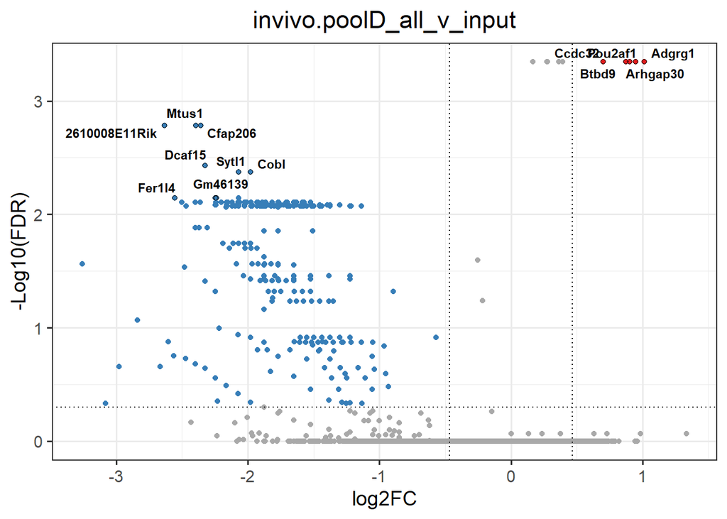

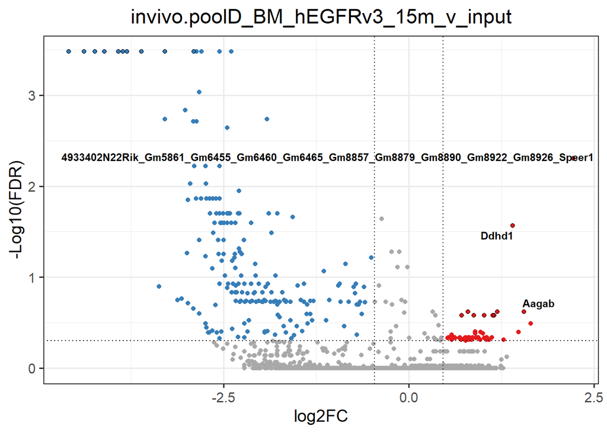

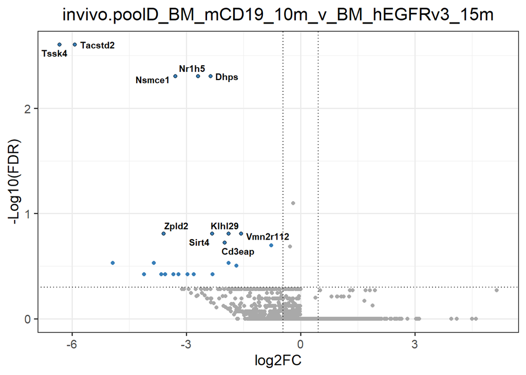

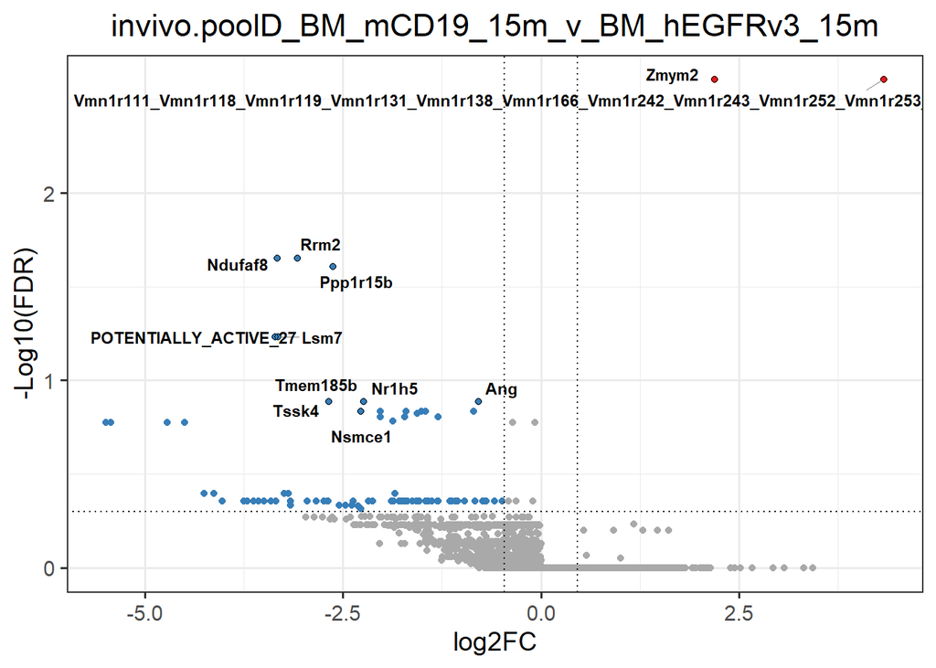

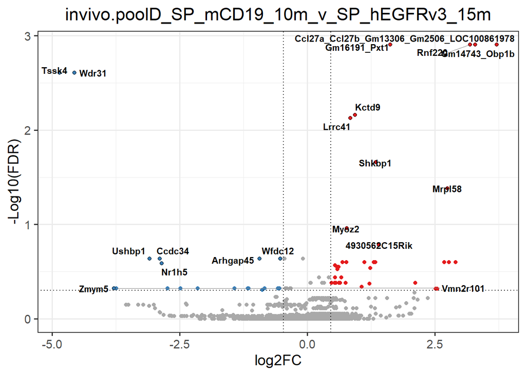

```r
for (i in files.toPlot){
  assign(paste0(i,".gdata"),ReadRRA(paste0(i,".gene_summary.txt"), score = c("lfc", "rra")[1]))
  assign(paste0(i,".sdata"),ReadsgRRA(paste0(i,".sgrna_summary.txt")))
}

for (i in files.toPlot){
  x <- get(paste0(i,".gdata"))
  print(plot_gdata_volcano(x))
}
```

## In Vivo Pool E

```r
invivo.poolE.1 <- ldf.200406[[5]][c(1,10)]
invivo.poolE.2 <- ldf.200627[[52]][c(1,3,20,21,22,23,24,39,40,41,42,43,44,45,46,47,48)]
invivo.poolE.3 <- ldf.200627[[59]][c(1,28,29,30,31,32,33,34,35,36,37,38)]

invivo.poolE <- merge(x=invivo.poolE.1,y=invivo.poolE.2, by.x=c("Construct.Barcode"),by.y=c("Construct.Barcode"), all=TRUE)
invivo.poolE <- merge(x=invivo.poolE,y=invivo.poolE.3, by.x=c("Construct.Barcode"),by.y=c("Construct.Barcode"), all=TRUE)
invivo.poolE <- merge(x=invivo.poolE,y=sgRNAs.gene, by.x=c("Construct.Barcode"),by.y=c("Barcode.Sequence"), all=FALSE, all.x=TRUE)

col.viv.poolE <- colnames(invivo.poolE)
```

```r
# reorder columns
invivo.poolE.reorder <- invivo.poolE[,c(1,30,2,
                                19,21,23,25,27,29,
                                9,11,14,16,18,
                                4,5,6,7,8,
                                3,20,22,24,26,28,
                                10,12,13,15,17)]

# replace NA values with 0
invivo.poolE.reorder <- replace(invivo.poolE.reorder, is.na(invivo.poolE.reorder), 0)
# Write to table for mageck run
write_delim(invivo.poolE.reorder,file="invivo.poolE.txt", delim = '\t')
```

### results import and plotting

```r
files.toPlot <- list.files(pattern=glob2rx("invivo.poolE_*gene_summary.txt"), full.names=FALSE)
files.toPlot <- str_replace(files.toPlot, ".gene_summary.txt", "")
files.toPlot
```

```
## [1] "invivo.poolE_all_v_input"
## [2] "invivo.poolE_BM_hEGFRv3_15m_v_input"
## [3] "invivo.poolE_BM_mCD19_10m_v_BM_hEGFRv3_15m"
## [4] "invivo.poolE_BM_mCD19_15m_v_BM_hEGFRv3_15m"
## [5] "invivo.poolE_SP_mCD19_10m_v_SP_hEGFRv3_15m"
```

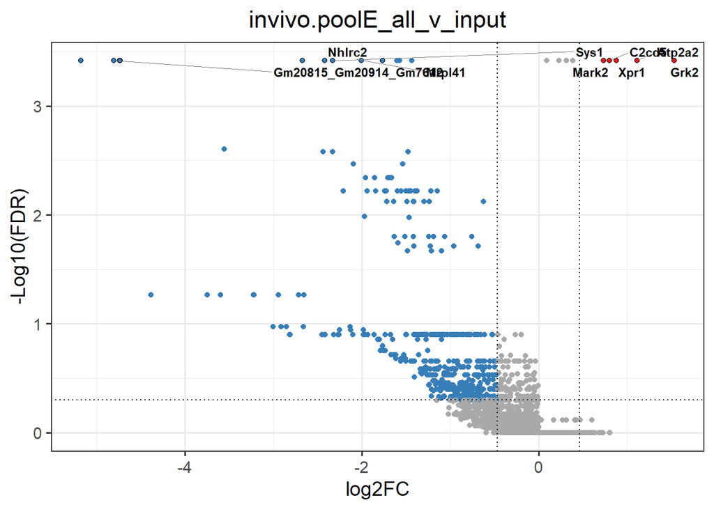

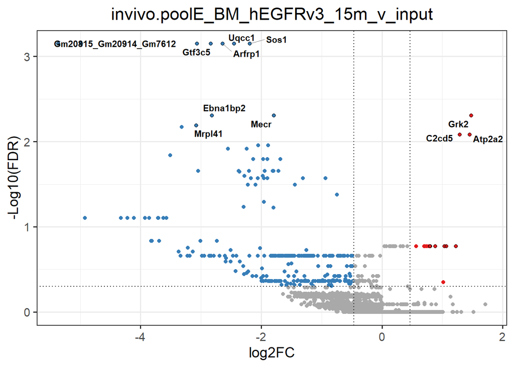

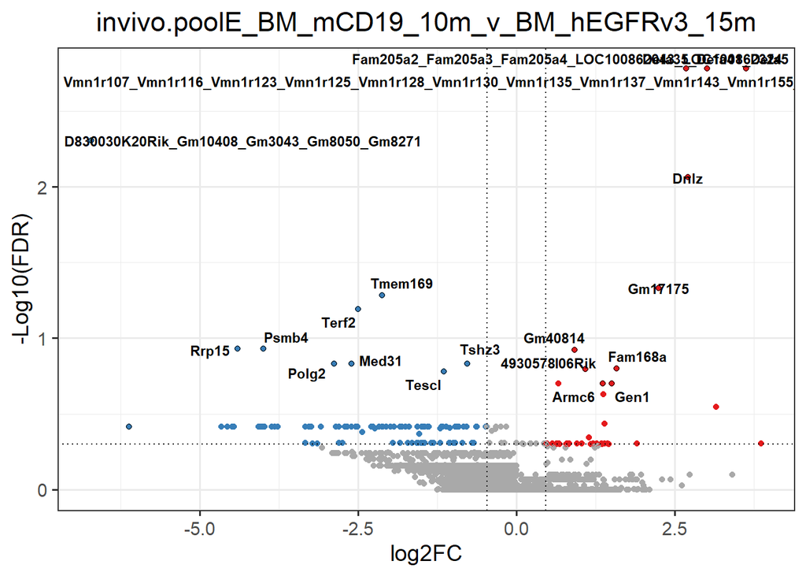

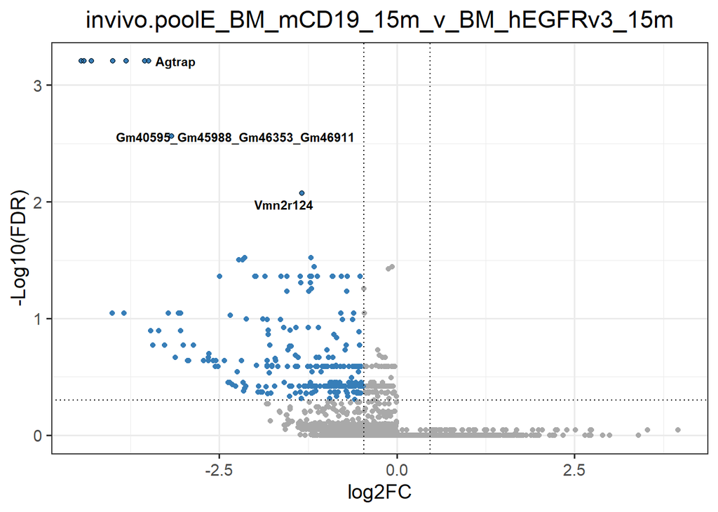

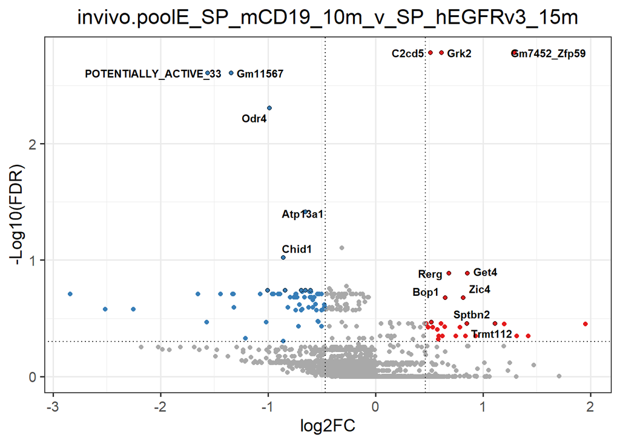

```r
for (i in files.toPlot){
  assign(paste0(i,".gdata"),ReadRRA(paste0(i,".gene_summary.txt"), score = c("lfc", "rra")[1]))
  assign(paste0(i,".sdata"),ReadsgRRA(paste0(i,".sgrna_summary.txt")))
}

for (i in files.toPlot){
  x <- get(paste0(i,".gdata"))
  print(plot_gdata_volcano(x))
}
```

## In Vivo Pool F

```r
invivo.poolF.1 <- ldf.200406[[6]][c(1,11)]
invivo.poolF.2 <- ldf.200627[[42]][c(1,3,4,5,6,7,8,9,11,12)]
invivo.poolF.3 <- ldf.200627[[53]][c(1,4,5,6,8,9,10,11,12,13,25,26,27,28,29,49,50)]

invivo.poolF <- merge(x=invivo.poolF.1,y=invivo.poolF.2, by.x=c("Construct.Barcode"),by.y=c("Construct.Barcode"), all=TRUE)
invivo.poolF <- merge(x=invivo.poolF,y=invivo.poolF.3, by.x=c("Construct.Barcode"),by.y=c("Construct.Barcode"), all=TRUE)
invivo.poolF <- merge(x=invivo.poolF,y=sgRNAs.gene, by.x=c("Construct.Barcode"),by.y=c("Barcode.Sequence"), all=FALSE, all.x=TRUE)

col.viv.poolF <- colnames(invivo.poolF)
```

```r
# reorder columns
invivo.poolF.reorder <- invivo.poolF[,c(1,28,2,
                                14,15,17,19,
                                3,5,7,10,26,
                                21,22,23,24,25,
                                13,16,18,20,
                                4,6,8,9,11,27)]

# replace NA values with 0
invivo.poolF.reorder <- replace(invivo.poolF.reorder, is.na(invivo.poolF.reorder), 0)
# Write to table for mageck run
write_delim(invivo.poolF.reorder,file="invivo.poolF.txt", delim = '\t')
```

### results import and plotting

```r
files.toPlot <- list.files(pattern=glob2rx("invivo.poolF_*gene_summary.txt"), full.names=FALSE)
files.toPlot <- str_replace(files.toPlot, ".gene_summary.txt", "")
files.toPlot
```

```
## [1] "invivo.poolF_all_v_input"
## [2] "invivo.poolF_BM_hEGFRv3_15m_v_input"
## [3] "invivo.poolF_BM_mCD19_10m_v_BM_hEGFRv3_15m"
## [4] "invivo.poolF_BM_mCD19_15m_v_BM_hEGFRv3_15m"
## [5] "invivo.poolF_SP_mCD19_10m_v_SP_hEGFRv3_15m"
```

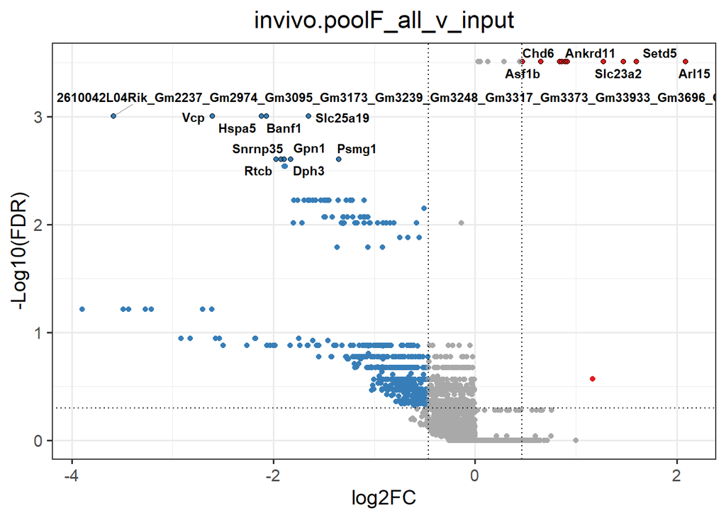

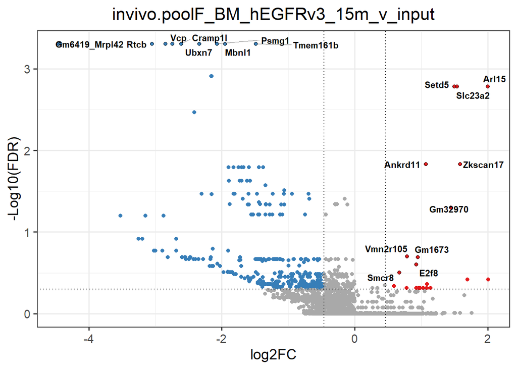

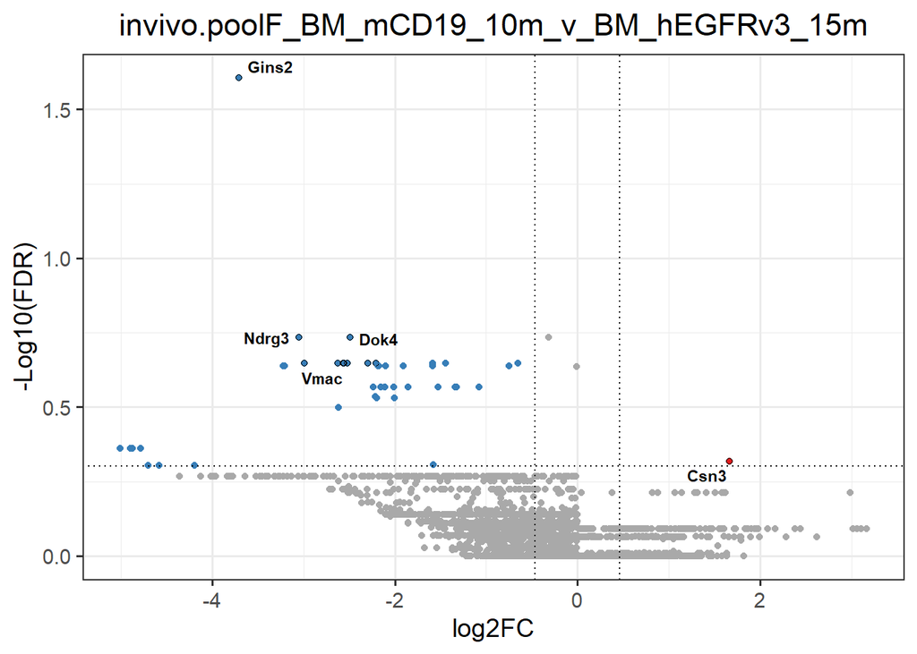

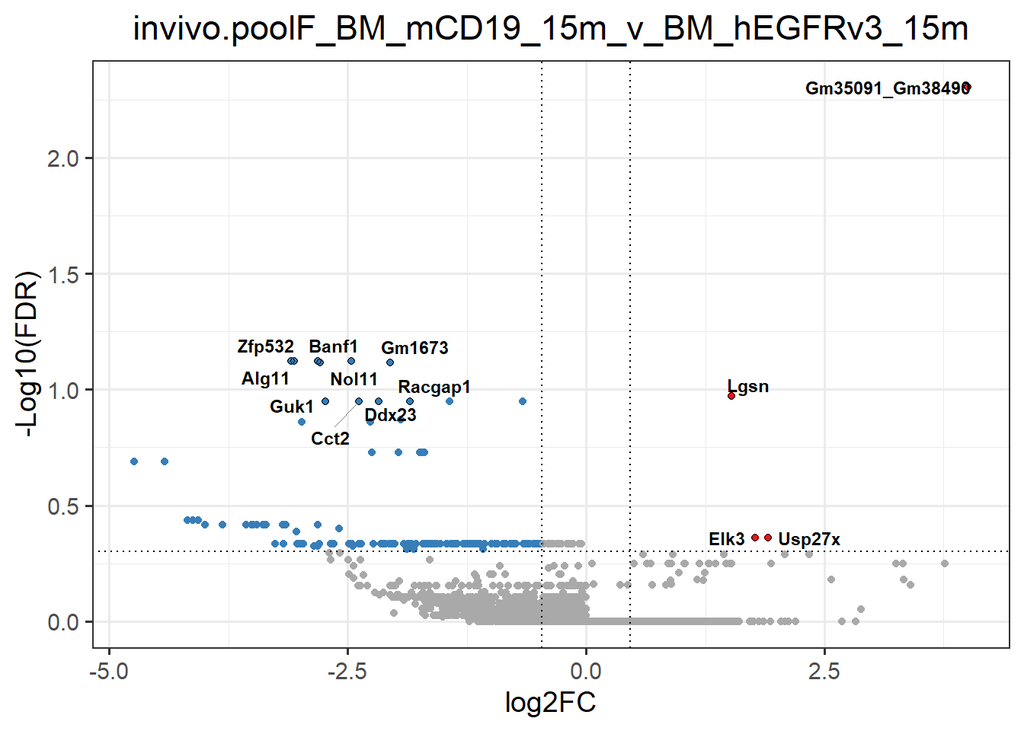

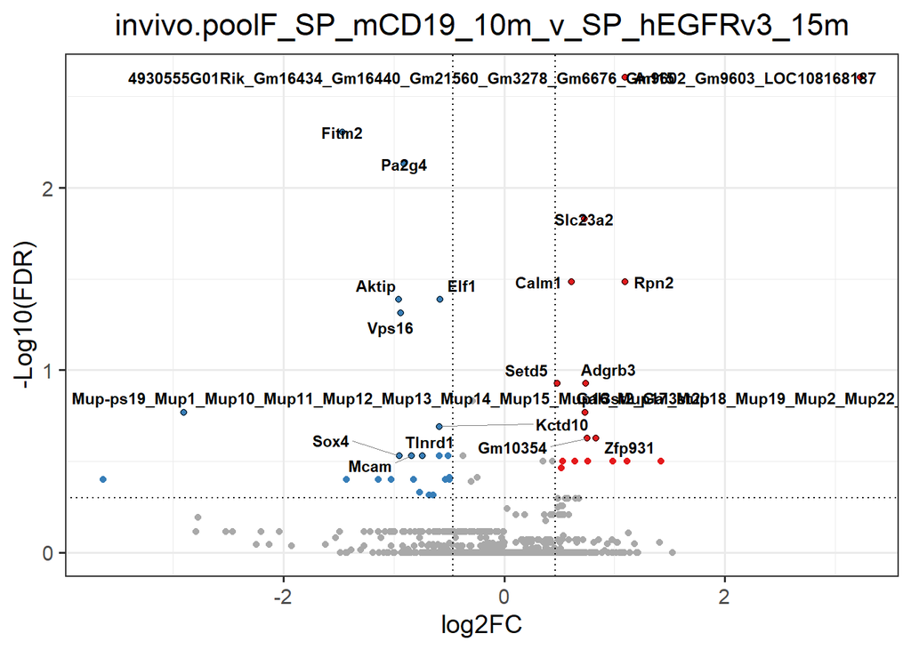

```r
for (i in files.toPlot){
  assign(paste0(i,".gdata"),ReadRRA(paste0(i,".gene_summary.txt"), score = c("lfc", "rra")[1]))
  assign(paste0(i,".sdata"),ReadsgRRA(paste0(i,".sgrna_summary.txt")))
}

for (i in files.toPlot){
  x <- get(paste0(i,".gdata"))
  print(plot_gdata_volcano(x))
}
```

# QC of selected data

There are a 2 samples that appear to have been sequenced multiple times. It would be inappropriate to use more than one of these technical replicates in analysis so decisions need to me made about which to select. These decisions were made based on “preSelect_” boxplots. When choice is not clear, first one was selected. Selection will be done my simply omitting the appropriate column index from the mageck scripts. Omitted samples are:

invitro.poolA.txt - 4 - 200406.1.17 - Pool.A..1.8._hEGFRv3.CAR_ET.1.10_rep3_1360..1361..1362..1363..1406..1407..1408..1409.x invitro.poolB.txt - 11 - 200627.63.5 - In.vitro_Pool.B..9.16._mCD19.CAR_ET.1.10_rep3_1410..1411..1412..1413..1414..1415..1416..1417.y

## QC plots of normalized data

```r
files.toPlot <- list.files(pattern=glob2rx("*all_v_input.normalized.txt"), full.names=FALSE)

# Create an empty list to store the ggplot objects
PCAdata <- list()
PCAplots <- list()

for (i in files.toPlot){
  plotTitle <- sub("_all_v_input.normalized.txt", "", i)
  norm <- read.table(i, row.names = 1, sep = "\t", header = TRUE)
  norm.l2 <- norm %>% select(-Gene)
  norm.l2 <- log2(norm.l2+1)
  dims <- dim(norm.l2)
  norm.l2 <- norm.l2 %>% rename_at(vars(everything()), ~str_replace_all(., "\\.\\.\\d+\\.\\d+\\.", "")) %>%
    rename_at(vars(everything()), ~str_replace_all(., "_\\d{4}\\.{2}\\d{4}\\.{2}\\d{4}\\.{2}\\d{4}\\.{2}\\d{4}\\.{2}\\d{4}\\.{2}\\d{4}\\.{2}\\d{4}", "")) %>%
    rename_at(vars(everything()), ~str_replace_all(., "In.vitro_", "")) %>%
    rename_at(vars(everything()), ~str_replace_all(., "In.vitro\\.", "")) %>%
    rename_at(vars(everything()), ~str_replace_all(., "In.vivo_", "")) %>%
    rename_at(vars(everything()), ~str_replace_all(., "In.vivo\\.", "")) %>%
    #rename_at(vars(everything()), ~str_replace_all(., "^AR\\d{4}_", "")) %>%
    rename_at(vars(everything()), ~str_replace_all(., "Pool\\.[ABCDEF]_", "")) %>%
    rename_at(vars(everything()), ~str_replace_all(., "_Pool\\.[ABCDEF]_.", "")) %>%
    rename_at(vars(everything()), ~str_replace_all(., "\\.Pool\\.[ABCDEF]", "")) %>%
    rename_at(vars(everything()), ~str_replace_all(., "_Pool\\.[ABCDEF]", "")) %>%
    rename_at(vars(everything()), ~str_replace_all(., "_rep", "_"))
  assign(paste0(plotTitle,".boxPlot"),
         ggplot(stack(norm.l2), aes(x = ind, y = values)) + geom_boxplot() + ylim(0, 12) +
           theme(axis.text.x = element_text(angle = 90, vjust = 0.5, hjust=1)) +
           ggtitle(paste0(plotTitle," - ",dims[1],"x",dims[2])))

  select.pca <- prcomp(t(norm.l2))
  var <- select.pca$sdev^2
  variance <- var/sum(var)
  percentVar <- select.pca$sdev^2 / sum(select.pca$sdev^2 )
  percentVar <- round(100 * percentVar,2)
  select.pca$percentVar <- percentVar
  select.pca$samps <- colnames(norm.l2)
  select.pca$samps <- select.pca$samps %>%
    str_replace_all(., "^AR\\d{4}_", "") %>%
    str_replace_all(., "\\.[xy]$", "") %>%
    str_replace_all(., "CAR_", "") %>%
    str_replace_all(., "_[123]$", "")
  data <- as.data.frame(select.pca$x)
  data$fill <- factor(select.pca$samps)
  plot <- ggplot(data, aes(x=PC1, y=PC2)) +
         geom_point(aes(fill = fill),shape=21, size = 4) +
         xlab(paste0("PC1 - ",select.pca$percentVar[1]," % of variability")) +
         ylab(paste0("PC2 - ",select.pca$percentVar[2]," % of variability")) +
    theme(legend.text = element_text(size = 8))
  PCAdata[[plotTitle]] <- data
  PCAplots[[plotTitle]] <- plot
}
```

### Assemble pairs of plots

```r
invitA <- ggarrange(invitro.poolA.boxPlot,PCAplots[[1]],nrow=2,ncol=1)
invitB <- ggarrange(invitro.poolB.boxPlot,PCAplots[[2]],nrow=2,ncol=1)
invitC <- ggarrange(invitro.poolC.boxPlot,PCAplots[[3]],nrow=2,ncol=1)
invitD <- ggarrange(invitro.poolD.boxPlot,PCAplots[[4]],nrow=2,ncol=1)
invitE <- ggarrange(invitro.poolD.boxPlot,PCAplots[[5]],nrow=2,ncol=1)
invitF <- ggarrange(invitro.poolF.boxPlot,PCAplots[[6]],nrow=2,ncol=1)

invivA <- ggarrange(invivo.poolA.boxPlot,PCAplots[[7]],nrow=2,ncol=1)
invivB <- ggarrange(invivo.poolB.boxPlot,PCAplots[[8]],nrow=2,ncol=1)
invivC <- ggarrange(invivo.poolC.boxPlot,PCAplots[[9]],nrow=2,ncol=1)
invivD <- ggarrange(invivo.poolD.boxPlot,PCAplots[[10]],nrow=2,ncol=1)
invivE <- ggarrange(invivo.poolE.boxPlot,PCAplots[[11]],nrow=2,ncol=1)
invivF <- ggarrange(invivo.poolF.boxPlot,PCAplots[[12]],nrow=2,ncol=1)

vit <- ggarrange(invitA,invitB,invitC,invitD,invitE,invitF,nrow=1,ncol=6)
viv <- ggarrange(invivA,invivB,invivC,invivD,invivE,invivF,nrow=1,ncol=6)
```

### Build final QC figures

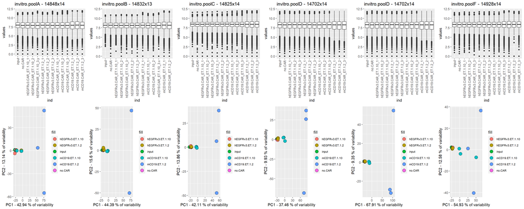

```r
vit
```

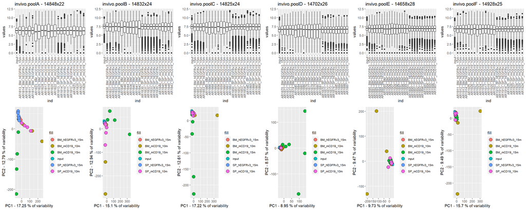

```r
viv
```

```r
#ggarrange(vit,viv,nrow=1,ncol=2)
```

## Volcano plots of hart essential genes in EGFR CAR vs Input comparisons

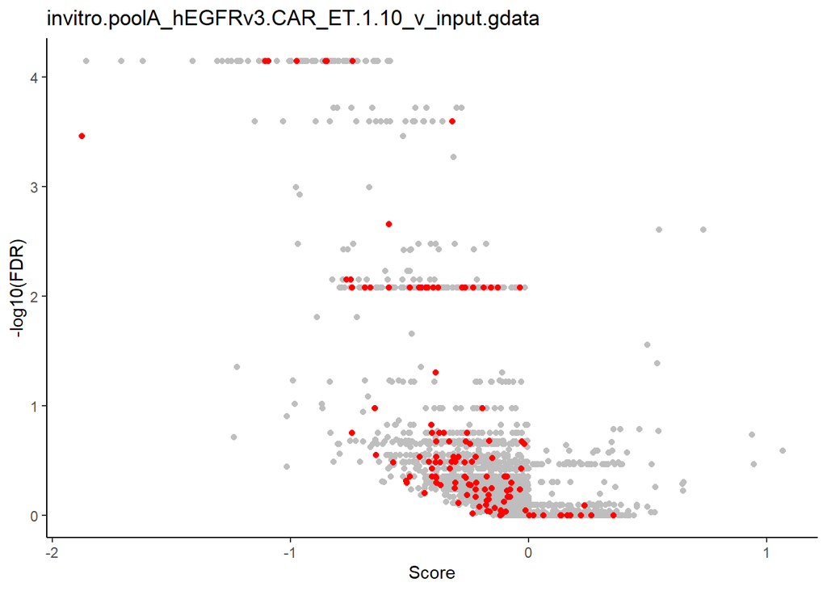

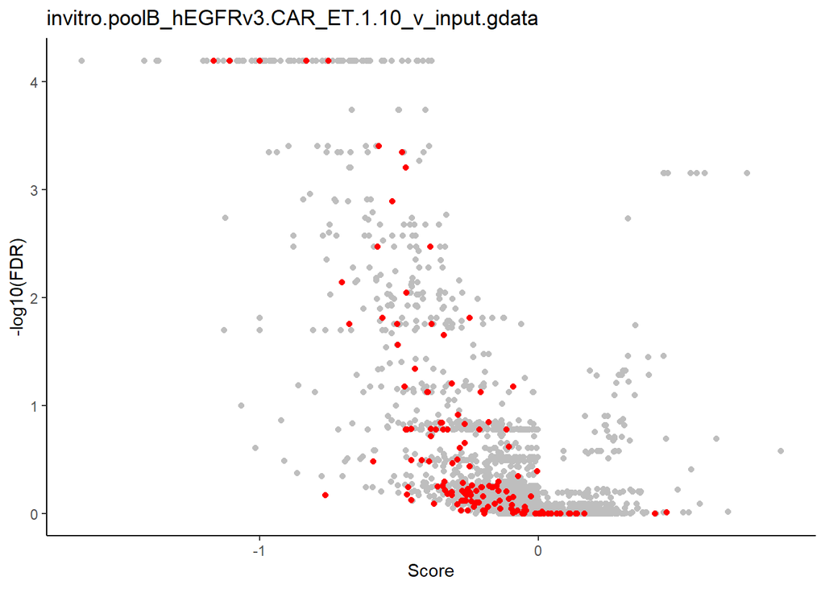

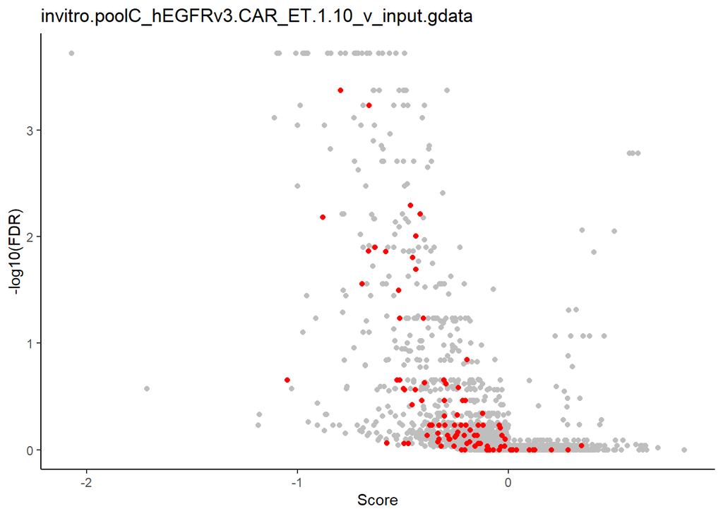

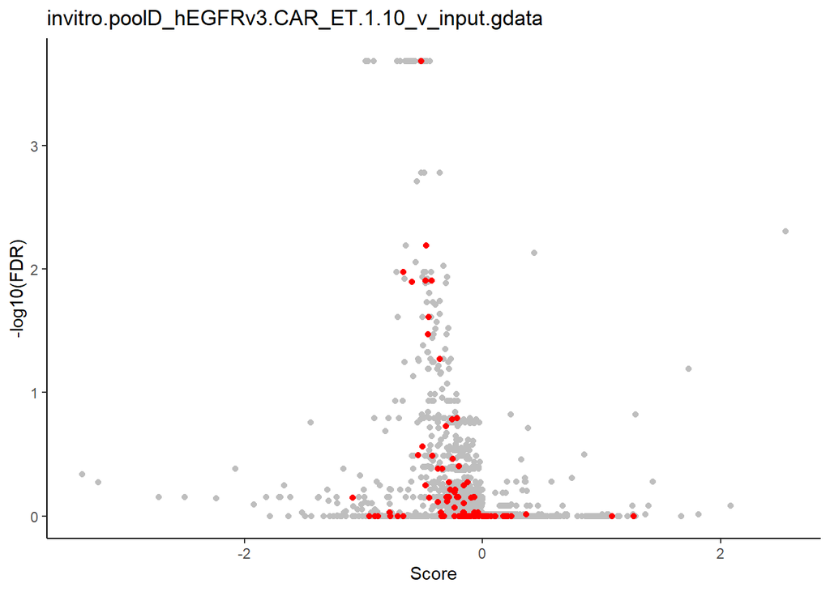

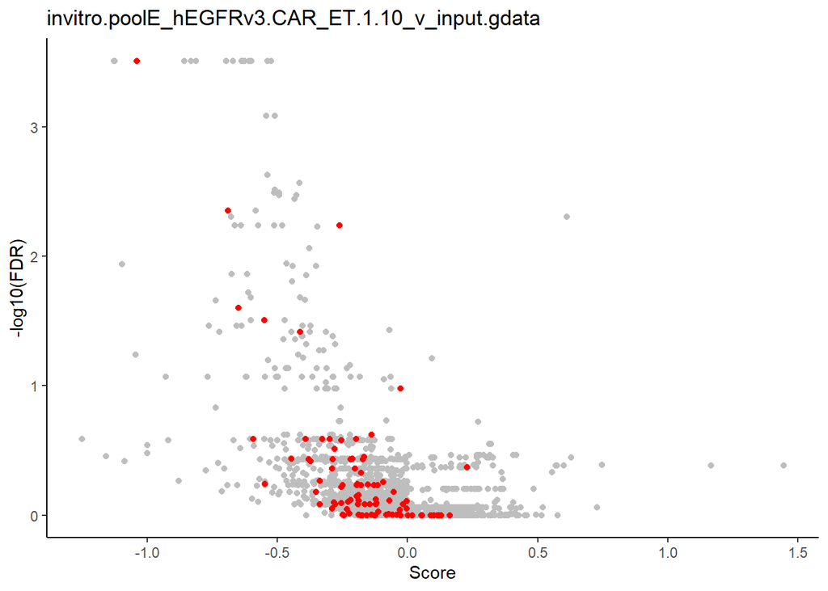

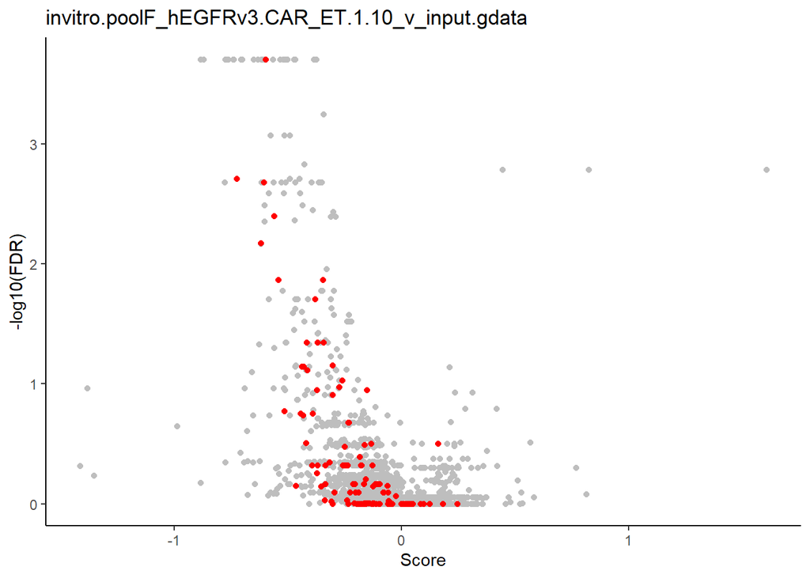

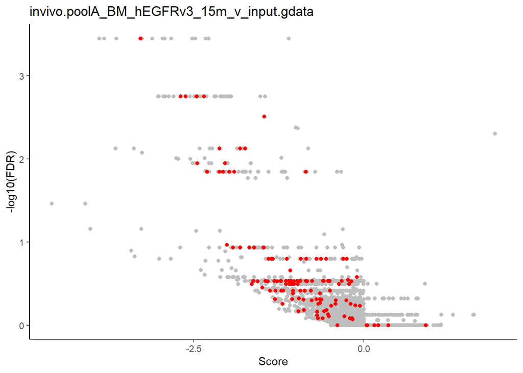

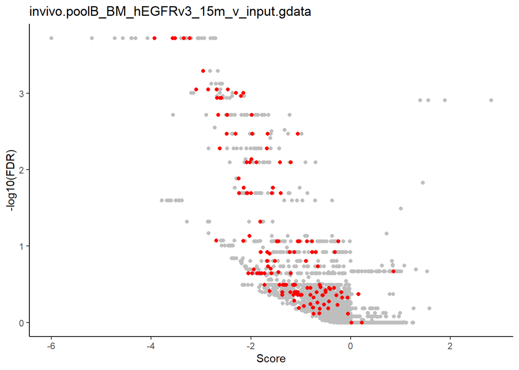

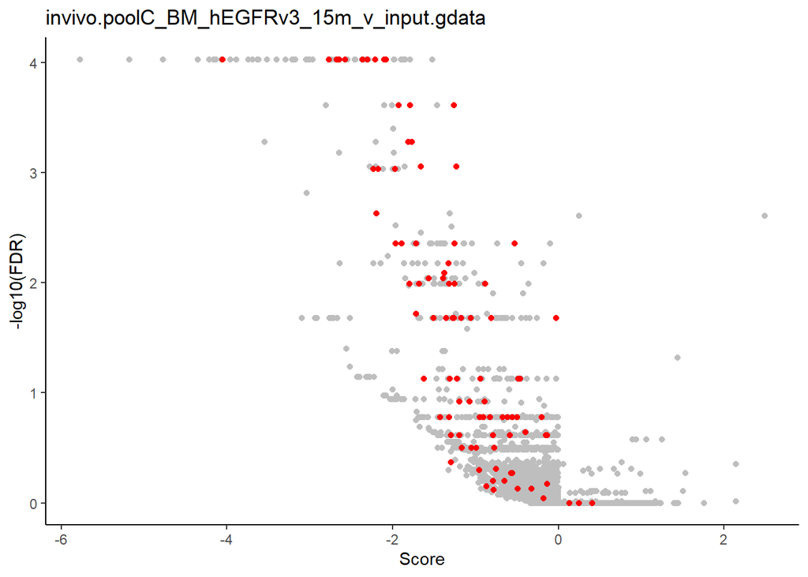

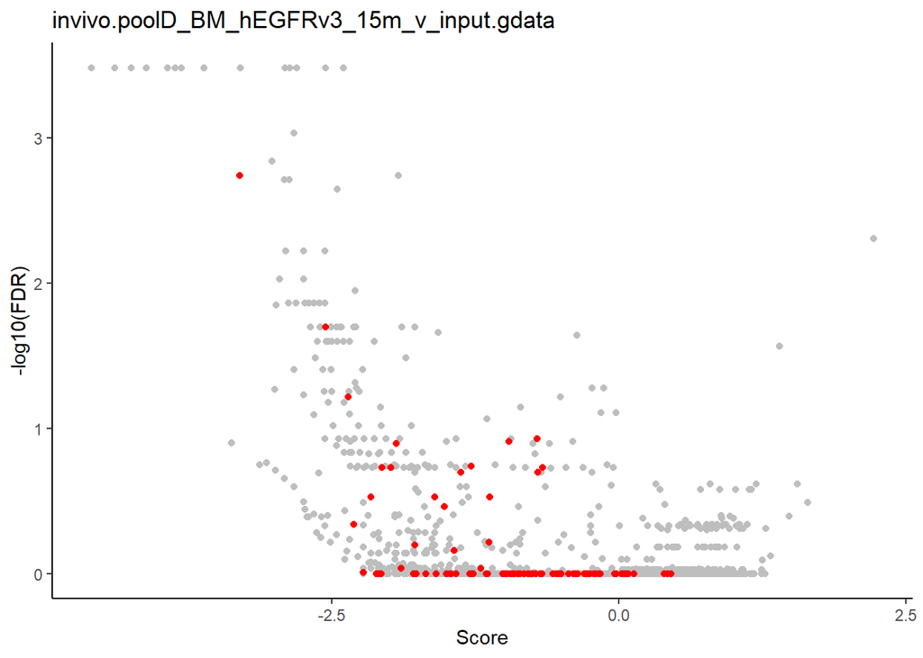

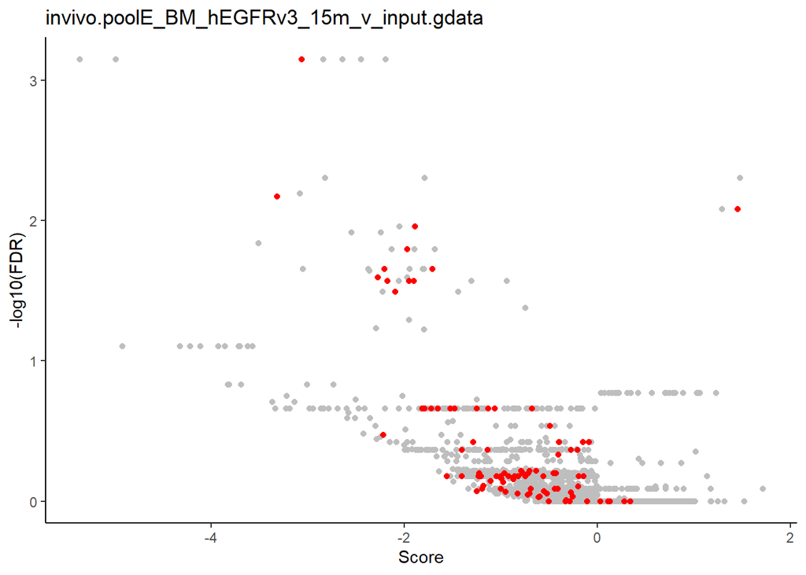

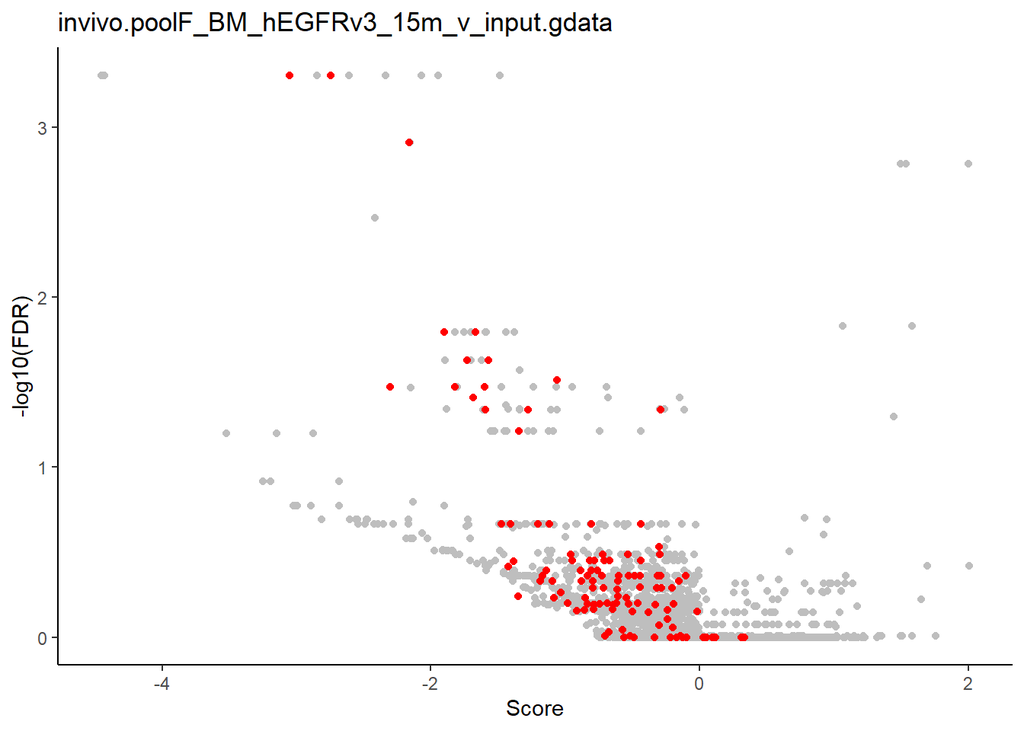

```r
gdata_obj <- ls(pattern=glob2rx("*input.gdata"))
gdata_obj <- grep("all", gdata_obj, invert = TRUE, value = TRUE)
for (i in 1:length(gdata_obj)){
  print(plot_essentials(get(gdata_obj[i])) + ggtitle(gdata_obj[i]))
}
```

## Box plots of essential genes in EGFR CAR vs Input comparisons

```r
gdata_obj <- ls(pattern=glob2rx("*input.gdata"))
gdata_obj <- grep("all", gdata_obj, invert = TRUE, value = TRUE)

EssentialPlot.plots <- list()

for (i in 1:length(gdata_obj)){
  plotTitle <- sub(".gdata", "", gdata_obj[[i]])
  plot <- vlnplot_essentials(get(gdata_obj[i])) + ggtitle(plotTitle)
  EssentialPlot.plots[[plotTitle]] <- plot
}
```

### The essential gene boxplots are available in resulting list

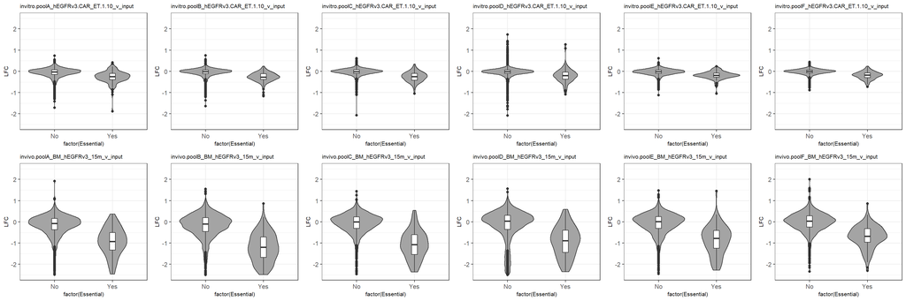

```r
ggarrange(EssentialPlot.plots[[1]],EssentialPlot.plots[[2]],EssentialPlot.plots[[3]],EssentialPlot.plots[[4]],EssentialPlot.plots[[5]],EssentialPlot.plots[[6]],
          EssentialPlot.plots[[7]],EssentialPlot.plots[[8]],EssentialPlot.plots[[9]],EssentialPlot.plots[[10]],EssentialPlot.plots[[11]],EssentialPlot.plots[[12]],
          nrow=2,ncol=6)
```

## Assembling the original screen re-analysis data

```r
invitro.1_10.gdata.list <- ls(pattern=glob2rx("invitro.*mCD19.CAR_ET.1.10_v_hEGFRv3.CAR_ET.1.10.gdata$"))

invitro.1_10.gdata.combined <- rbind(invitro.poolA_mCD19.CAR_ET.1.10_v_hEGFRv3.CAR_ET.1.10.gdata,
                                     invitro.poolB_mCD19.CAR_ET.1.10_v_hEGFRv3.CAR_ET.1.10.gdata,
                                     invitro.poolC_mCD19.CAR_ET.1.10_v_hEGFRv3.CAR_ET.1.10.gdata,
                                     invitro.poolD_mCD19.CAR_ET.1.10_v_hEGFRv3.CAR_ET.1.10.gdata,
                                     invitro.poolE_mCD19.CAR_ET.1.10_v_hEGFRv3.CAR_ET.1.10.gdata,
                                     invitro.poolF_mCD19.CAR_ET.1.10_v_hEGFRv3.CAR_ET.1.10.gdata)

invitro.1_10.gdata.combined <- rename(invitro.1_10.gdata.combined,invitro.1_10.Score = Score, invitro.1_10.FDR = FDR)

invitro.1_2.gdata.list <- ls(pattern=glob2rx("invitro.*mCD19.CAR_ET.1.2_v_hEGFRv3.CAR_ET.1.2.gdata$"))

invitro.1_2.gdata.combined <- rbind(invitro.poolA_mCD19.CAR_ET.1.2_v_hEGFRv3.CAR_ET.1.2.gdata,
                                     invitro.poolB_mCD19.CAR_ET.1.2_v_hEGFRv3.CAR_ET.1.2.gdata,
                                     invitro.poolC_mCD19.CAR_ET.1.2_v_hEGFRv3.CAR_ET.1.2.gdata,
                                     invitro.poolD_mCD19.CAR_ET.1.2_v_hEGFRv3.CAR_ET.1.2.gdata,
                                     invitro.poolE_mCD19.CAR_ET.1.2_v_hEGFRv3.CAR_ET.1.2.gdata,
                                     invitro.poolF_mCD19.CAR_ET.1.2_v_hEGFRv3.CAR_ET.1.2.gdata)

invitro.1_2.gdata.combined <- rename(invitro.1_2.gdata.combined,invitro.1_2.Score = Score, invitro.1_2.FDR = FDR)

invivo.BM_10.gdata.list <- ls(pattern=glob2rx("invivo.*BM_mCD19_10m_v_BM_hEGFRv3_15m.gdata$"))

invivo.BM_10.gdata.combined <- rbind(invivo.poolA_BM_mCD19_10m_v_BM_hEGFRv3_15m.gdata,
                                    invivo.poolB_BM_mCD19_10m_v_BM_hEGFRv3_15m.gdata,
                                    invivo.poolC_BM_mCD19_10m_v_BM_hEGFRv3_15m.gdata,
                                    invivo.poolD_BM_mCD19_10m_v_BM_hEGFRv3_15m.gdata,
                                    invivo.poolE_BM_mCD19_10m_v_BM_hEGFRv3_15m.gdata,
                                    invivo.poolF_BM_mCD19_10m_v_BM_hEGFRv3_15m.gdata)

invivo.BM_10.gdata.combined <- rename(invivo.BM_10.gdata.combined,invivo.BM_10.Score = Score, invivo.BM_10.FDR = FDR)

invivo.BM_15.gdata.list <- ls(pattern=glob2rx("invivo.*BM_mCD19_15m_v_BM_hEGFRv3_15m.gdata$"))

invivo.BM_15.gdata.combined <- rbind(invivo.poolA_BM_mCD19_15m_v_BM_hEGFRv3_15m.gdata,
                                    invivo.poolB_BM_mCD19_15m_v_BM_hEGFRv3_15m.gdata,
                                    invivo.poolC_BM_mCD19_15m_v_BM_hEGFRv3_15m.gdata,
                                    invivo.poolD_BM_mCD19_15m_v_BM_hEGFRv3_15m.gdata,
                                    invivo.poolE_BM_mCD19_15m_v_BM_hEGFRv3_15m.gdata,
                                    invivo.poolF_BM_mCD19_15m_v_BM_hEGFRv3_15m.gdata)

invivo.BM_15.gdata.combined <- rename(invivo.BM_15.gdata.combined,invivo.BM_15.Score = Score, invivo.BM_15.FDR = FDR)

invivo.SP_10.gdata.list <- ls(pattern=glob2rx("invivo.*SP_mCD19_10m_v_SP_hEGFRv3_15m.gdata$"))

invivo.SP_10.gdata.combined <- rbind(invivo.poolA_SP_mCD19_10m_v_SP_hEGFRv3_15m.gdata,
                                    invivo.poolB_SP_mCD19_10m_v_SP_hEGFRv3_15m.gdata,
                                    invivo.poolC_SP_mCD19_10m_v_SP_hEGFRv3_15m.gdata,
                                    invivo.poolD_SP_mCD19_10m_v_SP_hEGFRv3_15m.gdata,
                                    invivo.poolE_SP_mCD19_10m_v_SP_hEGFRv3_15m.gdata,
                                    invivo.poolF_SP_mCD19_10m_v_SP_hEGFRv3_15m.gdata)

invivo.SP_10.gdata.combined <- rename(invivo.SP_10.gdata.combined,invivo.SP_10.Score = Score, invivo.SP_10.FDR = FDR)
```

## Checking combined data

```r
combined.list <- ls(pattern=("*gdata.combined$"))

for (i in combined.list){
  print(dim(get(i)))
}
```

```
## [1] 23427     3
## [1] 23411     3
## [1] 23135     3
## [1] 23054     3
## [1] 23268     3
```

```r
for (i in combined.list){
  print(head(get(i)))
}
```

```
##      id invitro.1_10.Score invitro.1_10.FDR
## 1 Ptpn1           -2.38650         0.000990
## 2  Atg7           -1.08740         0.000990
## 3 Ptpn2           -1.54680         0.000990
## 4 Dusp5           -0.72109         0.000990
## 5  Irf9           -0.65375         0.002475
## 6 Hdac1           -0.65450         0.004332
##      id invitro.1_2.Score invitro.1_2.FDR
## 1 Ptpn1           -2.4196        0.000619
## 2 Cflar           -1.2603        0.000619
## 3 Ptprc           -1.4748        0.000619
## 4 Ptpn2           -1.1463        0.000619
## 5 Stt3a           -1.3627        0.000619
## 6  Irf9           -0.9830        0.000619
##       id invivo.BM_10.Score invivo.BM_10.FDR
```

[output cut: 20 more lines]

## Merging original screen re-analysis

```r
#combined.objects <- mget(combined.list)
#combined.df <- combined.objects %>% reduce(inner_join, by='gene')

geneLevel <- left_join(invitro.1_10.gdata.combined, invitro.1_2.gdata.combined, by = "id") %>%
  left_join(invivo.BM_10.gdata.combined, by = "id") %>%
  left_join(invivo.BM_15.gdata.combined, by = "id") %>%
  left_join(invivo.SP_10.gdata.combined, by = "id")
```

### Gene Level Whitelist and other annotations

```r
geneLevel.annotated <- merge(geneLevel,GeneSymWhitelist,by.x = 'id', by.y = 'GeneSym',all=TRUE)
geneLevel.annotated <- merge(geneLevel.annotated,biocarta.ifng,by.x = 'id', by.y = 'Gene',all=TRUE)
geneLevel.annotated <- merge(geneLevel.annotated,hallmark.ifng,by.x = 'id', by.y = 'Gene',all=TRUE)
geneLevel.annotated <- merge(geneLevel.annotated,mmKEGG.toJoin,by.x = 'id', by.y = 'MmSym',all=TRUE)
geneLevel.annotated.whitelist <- geneLevel.annotated %>% dplyr::filter(geneSym.whitelist == "Yes")

write.xlsx(geneLevel.annotated.whitelist, file="geneLevel.annotated.whitelist.xlsx", overwrite = TRUE, rowNames=TRUE)
```

```r
writeLines(capture.output(sessionInfo()), "B-ALL_primaryScreen_sessionInfo.txt")
```